# Assignment 2: Spatial Analysis and Visualization

```r
# Calculate the "education coverage rate" and "child density" of each census tracts

## 1) Area (m²) and child density (per square kilometer)

tracts_metrics <- phl_tracts_5070 %>%
  mutate(tract_area_m2 = as.numeric(st_area(geometry)),
         tract_area_km2 = tract_area_m2 / 1e6) %>%
  left_join(tracts_with_children %>% st_drop_geometry() %>%
              select(GEOID, child_pop = child_popE), by = "GEOID") %>%
  mutate(child_density = ifelse(tract_area_km2 > 0, child_pop / tract_area_km2, NA_real_))

## 2) Coverage rate = Intersection area between the reachable zone and the census zone (m²)
intersect_access <- st_intersection(
  tracts_metrics %>% select(GEOID),
  st_make_valid(access_union_core)
) %>%
  mutate(access_area_m2 = as.numeric(st_area(geometry))) %>%
  st_drop_geometry() %>%
  group_by(GEOID) %>%
  summarize(access_area_m2 = sum(access_area_m2, na.rm = TRUE), .groups = "drop")

tracts_metrics <- tracts_metrics %>%
  left_join(intersect_access, by = "GEOID") %>%
  mutate(access_area_m2 = coalesce(access_area_m2, 0),
         access_ratio   = pmin(access_area_m2 / tract_area_m2, 1))

## 3)Check the statistical distribution of child_density and access_ratio
summary(tracts_metrics[, c("child_density", "access_ratio")])
```

```
 child_density      access_ratio             geometry
 Min.   :    0.0   Min.   :0.0000   MULTIPOLYGON :408
 1st Qu.:  565.8   1st Qu.:0.5494   epsg:5070    :  0
 Median : 1276.6   Median :0.8909   +proj=aea ...:  0
 Mean   : 1495.1   Mean   :0.7438
 3rd Qu.: 2175.0   3rd Qu.:1.0000
 Max.   :10064.8   Max.   :1.0000
```

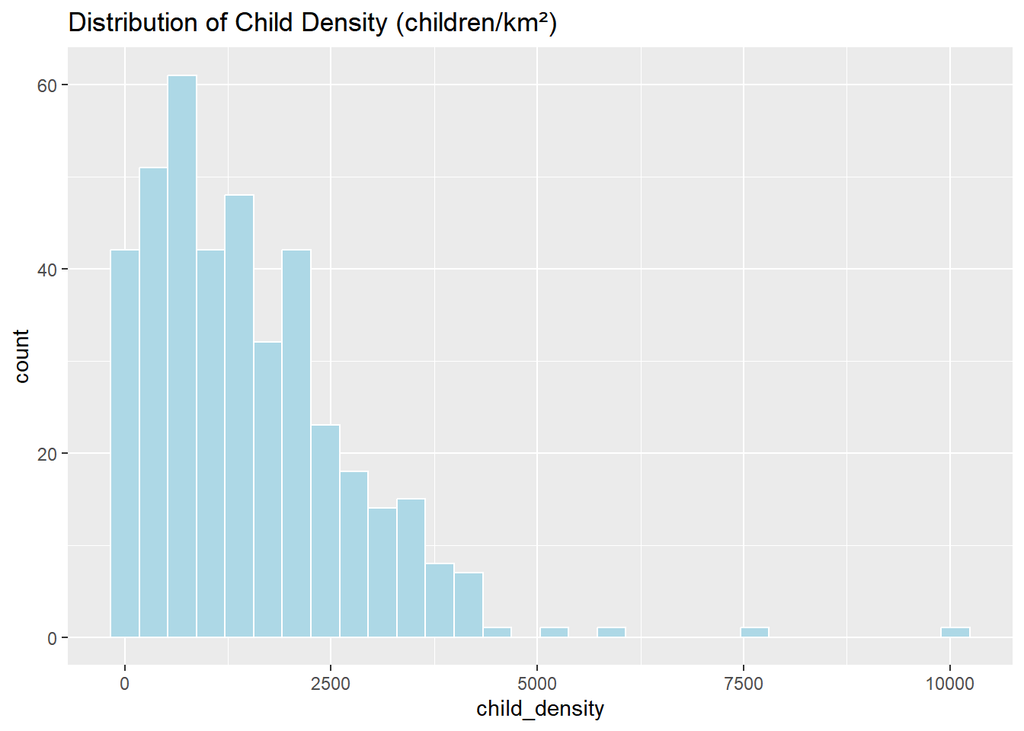

```r
ggplot(tracts_metrics) +
  geom_histogram(aes(x = child_density), bins = 30, fill = "lightblue", color = "white") +
  labs(title = "Distribution of Child Density (children/km²)")
```

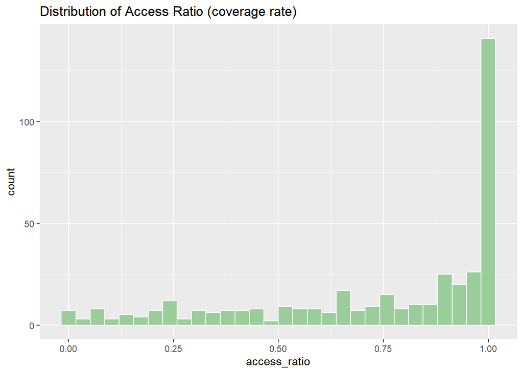

```r
ggplot(tracts_metrics) +
  geom_histogram(aes(x = access_ratio), bins = 30, fill = "darkseagreen3", color = "white") +
  labs(title = "Distribution of Access Ratio (coverage rate)")
```

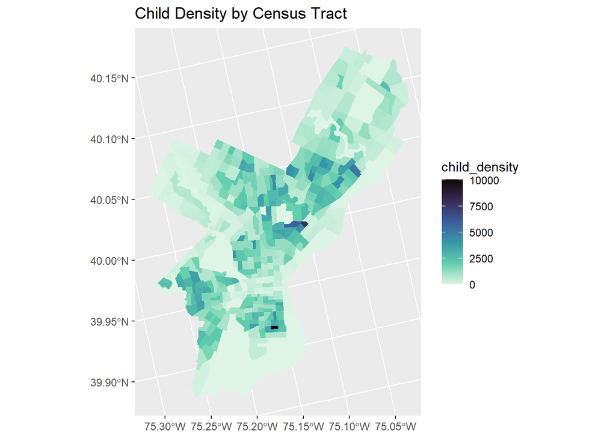

```r
ggplot() +
  geom_sf(data = tracts_metrics, aes(fill = child_density), color = NA) +
  scale_fill_viridis_c(option="mako", direction=-1) +
  labs(title = "Child Density by Census Tract")
```

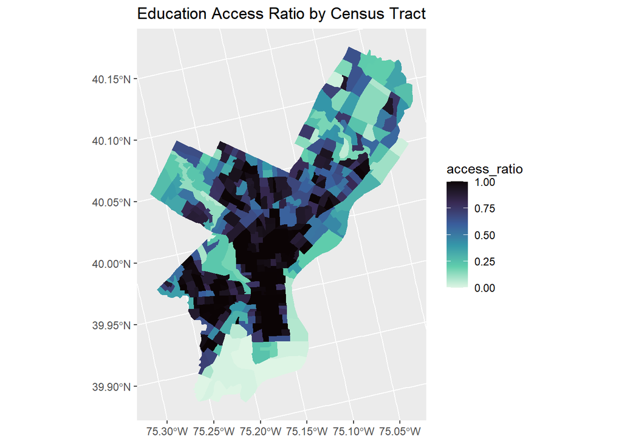

```r
ggplot() +
  geom_sf(data = tracts_metrics, aes(fill = access_ratio), color = NA) +
  scale_fill_viridis_c(option="mako", direction=-1) +
  labs(title = "Education Access Ratio by Census Tract")
```

```r
# Define education desert

p_target <- 0.25

tracts_metrics <- tracts_metrics %>%
  mutate(
    z_child   = as.numeric(scale(child_density)),
    z_access  = as.numeric(scale(-access_ratio)),
    score     = 0.5 * z_child + 0.5 * z_access
  ) %>%
  mutate(
    cutoff = quantile(score, 1 - p_target, na.rm = TRUE),
    vulnerable_local = score >= cutoff
  )


cutoff_value <- unique(tracts_metrics$cutoff)
count_table  <- table(tracts_metrics$vulnerable_local)
percent_vuln <- mean(tracts_metrics$vulnerable_local, na.rm = TRUE)

summary_vulnerable <- tibble(
  Metric = c("Cutoff Score",
             "Tracts classified as TRUE (Educational Desert)",
             "Tracts classified as FALSE",
             "Share of Desert Tracts"),
  Value = c(
    round(cutoff_value, 3),
    as.integer(count_table["TRUE"]),
    as.integer(count_table["FALSE"]),
    paste0(round(percent_vuln * 100, 1), "%")
  )
)

kable(summary_vulnerable, caption = "Summary of Educational Desert Classification")
```

Summary of Educational Desert Classification

| Metric | Value |
| --- | --- |
| Cutoff Score | 0.352 |
| Tracts classified as TRUE (Educational Desert) | 102 |
| Tracts classified as FALSE | 306 |
| Share of Desert Tracts | 25% |

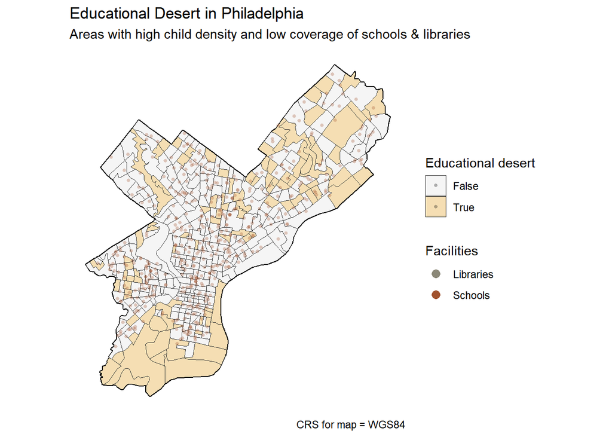

```r
# Draw the map

## 1) Back to WGS84
tracts_map           <- st_transform(tracts_metrics, crs_map)
phl_boundary_plot    <- st_transform(phl_boundary_5070, crs_map)
schools_plot         <- st_transform(schools, crs_map) %>% mutate(Type = "Schools")
libraries_plot       <- st_transform(libraries_phl, crs_map) %>% mutate(Type = "Libraries")

facilities <- dplyr::bind_rows(
  dplyr::select(schools_plot,  Type),
  dplyr::select(libraries_plot, Type)
)

## 2) map
ggplot() +
  geom_sf(
    data = tracts_map,
    aes(fill = vulnerable_local),
    color = "grey20", size = 0.15
  ) +
  geom_sf(
    data = phl_boundary_plot,
    fill = NA, color = "black", linewidth = 0.4
  ) +
  geom_sf(
    data = facilities,
    aes(color = Type),
    shape = 16,
    size = 1,
    alpha = 0.3,
    show.legend = TRUE
  ) +
  scale_fill_manual(
    values = c("FALSE" = "whitesmoke", "TRUE" = "wheat"),
    name = "Educational desert",
    labels = c("False", "True")
  ) +
  scale_color_manual(
    name = "Facilities",
    values = c("Schools" = "sienna", "Libraries" = "cornsilk4", alpha = 0.3)
  ) +
  guides(
    color = guide_legend(override.aes = list(shape = 16, size = 3, alpha = 1))
  ) +
  labs(
    title = "Educational Desert in Philadelphia",
    subtitle = "Areas with high child density and low coverage of schools & libraries",
    caption = "CRS for map = WGS84"
  ) +
  theme_minimal() +
  theme(
    legend.position = "right",
    axis.text = element_blank(),
    axis.ticks = element_blank(),
    panel.grid = element_blank()
  )
```

```r
legend_table <- tibble(
  Category = c("Educational Desert", "Schools", "Libraries"),
  Meaning = c("High child density, low access",
              "Education facilities",
              "Public libraries providing learning access")
)
kable(legend_table, caption = "Legend Explanation")
```

Legend Explanation

| Category | Meaning |
| --- | --- |
| Educational Desert | High child density, low access |
| Schools | Education facilities |
| Libraries | Public libraries providing learning access |

```r
# Sensitivity test (add Recreation Centers)

## 1) Calculate the coverage rate after adding recreation centers"
intersect_access_all <- st_intersection(
  tracts_metrics %>% select(GEOID),
  st_make_valid(access_union_all)
) %>%
  mutate(access_area_m2_all = as.numeric(st_area(geometry))) %>%
  st_drop_geometry() %>%
  group_by(GEOID) %>%
  summarize(access_area_m2_all = sum(access_area_m2_all, na.rm = TRUE), .groups = "drop")

tracts_metrics_all <- tracts_metrics %>%
  left_join(intersect_access_all, by = "GEOID") %>%
  mutate(
    access_area_m2_all = coalesce(access_area_m2_all, 0),
    access_ratio_all   = pmin(access_area_m2_all / tract_area_m2, 1),
    z_access_all       = as.numeric(scale(-access_ratio_all)),

    score_all          = 0.5 * z_child + 0.5 * z_access_all
  ) %>%
  mutate(
    cutoff_all = quantile(score_all, 1 - p_target, na.rm = TRUE),
    vulnerable_all = score_all >= cutoff_all
  )

## 2) Compare with the previous results
sens_compare <- tracts_metrics_all %>%
  st_drop_geometry() %>%
  select(GEOID, vulnerable_core = vulnerable_local, vulnerable_all)

sens_compare <- sens_compare %>%
  mutate(
    status = dplyr::case_when(
      vulnerable_core &  vulnerable_all  ~ "Stable: Desert",
      !vulnerable_core & !vulnerable_all ~ "Stable: Not Desert",
      vulnerable_core & !vulnerable_all  ~ "Flipped: Rescued by Rec",
      !vulnerable_core &  vulnerable_all ~ "Flipped: Newly Desert",
      TRUE ~ "Other"
    )
  )

## 3) Summary table for sensitivity
total_tracts <- nrow(sens_compare)
sens_table <- sens_compare %>%
  count(status, name = "Count") %>%
  mutate(Share = paste0(round(100 * Count / total_tracts, 1), "%")) %>%
  arrange(desc(Count))

## 4) The degree of overlap between two sets of "deserts"
jaccard <- with(sens_compare, sum(vulnerable_core & vulnerable_all, na.rm = TRUE) /
                  sum(vulnerable_core | vulnerable_all, na.rm = TRUE))


kable(
  bind_rows(
    sens_table,
    tibble(
      status = "Jaccard (core vs all)",
      Count  = NA_integer_,
      Share  = paste0(round(jaccard * 100, 1), "%")
    )
  ),
  caption = "Sensitivity: Effect of Adding Recreation Centers on 'Educational Desert' Classification"
)
```

Sensitivity: Effect of Adding Recreation Centers on ‘Educational Desert’ Classification

| status | Count | Share |
| --- | --- | --- |
| Stable: Not Desert | 297 | 72.8% |
| Stable: Desert | 93 | 22.8% |
| Flipped: Newly Desert | 9 | 2.2% |
| Flipped: Rescued by Rec | 9 | 2.2% |
| Jaccard (core vs all) | NA | 83.8% |

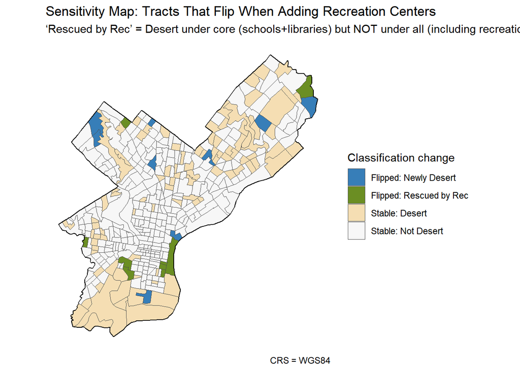

```r
# Map the "flipped" tracts

## 1) reproject CRS to WGS 84
tracts_status_map <- tracts_metrics %>%
  select(GEOID, geometry) %>%
  left_join(sens_compare %>% select(GEOID, status), by = "GEOID") %>%
  st_transform(crs_map)

ggplot() +
  geom_sf(data = tracts_status_map, aes(fill = status), color = "grey30") +
  geom_sf(data = phl_boundary_plot, fill = NA, color = "black", linewidth = 0.4) +

  scale_fill_manual(
    name = "Classification change",
    values = c(
      "Stable: Desert"        = "wheat",
      "Stable: Not Desert"    = "#f7f7f7",
      "Flipped: Rescued by Rec" = "olivedrab",
      "Flipped: Newly Desert" = "#377eb8"
    )
  ) +
  scale_color_manual(
    name = "Facilities",
    values = c("Schools" = "mistyrose3", "Libraries" = "cornsilk4")
  ) +
  guides(
    color = guide_legend(override.aes = list(shape = 16, size = 3, alpha = 1))
  ) +
  labs(
    title = "Sensitivity Map: Tracts That Flip When Adding Recreation Centers",
    subtitle = "‘Rescued by Rec’ = Desert under core (schools+libraries) but NOT under all (including recreation)",
    caption = "CRS = WGS84"
  ) +
  theme_minimal() +
  theme(
    legend.position = "right",
    axis.text = element_blank(),
    axis.ticks = element_blank(),
    panel.grid = element_blank()
  )
```

**Analysis requirements:**

- Clear code comments explaining each step
- Appropriate CRS transformations
- Summary statistics or counts
- At least one map showing your findings
- Brief interpretation of results (3-5 sentences)

**Limitations:** - The “desert” share is **fixed at 25%**, meaning results indicate relative prioritization, not the true shortage of facilities. Even if new schools are added, there will always be a top 25%.

- Access is purely spatial—distance-based—without accounting for **facility capacity, quality, or transportation barriers**. It measures potential accessibility, not real educational equity.
- Equal weights (0.5/0.5) are simple but subjective; weights should ideally reflect policy priorities or empirical evidence.

## Finally - A few comments about your incorporation of feedback!

- To make sure that I can take responsibilities to my codes, I added comment lines everywhere I might need.
- To make sure the tables are readable for both readers and me, I visualized important results of every chunk in part 3.

## Submission Requirements

**What to submit:**

1. **Rendered HTML document posted to your course portfolio** with all code, outputs, maps, and text
   - Use `embed-resources: true` in YAML so it’s a single file
   - All code should run without errors
   - All maps and charts should display correctly

**File naming:** `LastName_FirstName_Assignment2.html` and `LastName_FirstName_Assignment2.qmd`